# Tiny numbers are actually tiny

Greg Woodin, Bodo Winter, Marcus Perlman, Teenie Matlock

09/11/2018

This is the code used for the analysis reported in ‘Tiny numbers are actually tiny: Spatial associations of quantity in gesture’.

# Tiny vs. huge

Load the packages used, load tiny/huge numbers dataset and give it a shorter name for easier coding:

```r
# Packages:
library(tidyverse)    # Data processing and visualisation
library(tidyr)    # Data processing and visualisation
library(dplyr)    # Writing for loops
library(lme4)   # Fitting logistic regression models
library(effects)    # Plotting logistic regression models
library(brms)   # Fitting Bayesian models

# Data:
(size <- read_csv('tinyhuge_alldata_coded.csv'))
```

```
## # A tibble: 804 x 31
##       ID URL   Archive_ID Title SpeakerName HasPhrase Phrase Negated Plural
##    <int> <chr> <chr>      <chr> <chr>       <chr>     <chr>  <chr>   <chr>
##  1  4939 http… CSPAN2_20… Toni… iain dunca… yes       huge_… no      no
##  2  9433 http… MSNBC_201… Hard… anita dunn  yes       huge_… no      no
##  3   338 http… CSPAN_201… Wash… claire mcc… yes       tiny_… no      no
##  4  1715 http… FOXNEWS_2… The … steven cen… yes       huge_… no      no
##  5   356 http… CSPAN_201… Key … james jay … yes       tiny_… no      no
##  6   204 http… KQED_2014… PBS … <NA>        yes       tiny_… no      no
##  7  6449 http… CNBC_2014… Squa… jim cramer  yes       huge_… no      no
##  8  5865 http… CSPAN3_20… Poli… thilo kosl… yes       huge_… no      no
##  9   368 http… CSPAN2_20… Toda… john harwo… yes       tiny_… no      no
## 10  9593 http… CNN_20120… CNN … haroon mog… yes       huge_… yes     no
## # ... with 794 more rows, and 22 more variables: SpeakerVisible <chr>,
## #   HandsVisible <chr>, HandsVisibleGenerous <chr>, HandsFree <chr>,
## #   HandsMoving <chr>, NounPlural <chr>, ContextMove <chr>,
## #   Duplicated <chr>, WhichHand <chr>, HandConfig <chr>, PinchType <chr>,
## #   PinkieCurl <chr>, PalmOrientation <chr>, MovementVertical <chr>,
## #   MovementHorizontal <chr>, MovementSagittal <chr>, QuantityType <chr>,
## #   QuantityValue <chr>, VerbatimReferent <chr>, QuantityContrast <chr>,
## #   OfInterest <chr>, Comments <chr>
```

Reduce dataset to only those videos which were analysable from a gestural perspective:

```r
# Overall:
nrow(size)
```

```
## [1] 804
```

```r
# HasPhrase == "yes":
size <- filter(size, HasPhrase != "no")
nrow(size)
```

```
## [1] 746
```

```r
# SpeakerVisible == "yes":
size <- filter(size, SpeakerVisible != "no")
nrow(size)
```

```
## [1] 553
```

```r
# HandsVisibleGenerous == "one" or "both":
size <- filter(size, HandsVisibleGenerous != "neither")
nrow(size)
```

```
## [1] 272
```

```r
# HandsFree == "one" or "both":
size <- filter(size, HandsFree != "neither")
nrow(size)
```

```
## [1] 253
```

```r
# Negated == 'NA' or "no":
size <- filter(size, is.na(Negated) | Negated != "yes")
nrow(size)
```

```
## [1] 246
```

```r
# ContextMove == 'NA' or 'yes' videos:
size <- filter(size, is.na(ContextMove) | ContextMove != "no")
nrow(size)
```

```
## [1] 243
```

Find out which speakers appear in the dataset more than once so duplicate videos can be removed manually:

```r
n_occur <- data.frame(table(size$SpeakerName))    # Create table of all speakers
filter(n_occur, Freq > 1)   # Filter to only those speakers that appear more than once
```

```
##                     Var1 Freq
## 1           atul gawande    6
## 2           barack obama    3
## 3         bernie sanders    4
## 4          brad wiegmann    2
## 5          cliff stearns    2
## 6           david vitter    3
## 7            dean baquet    4
## 8           doris fuller    2
## 9        edward miliband    2
## 10      elaine showalter    5
## 11      elizabeth warren    2
## 12          eric schmidt    2
## 13            guy taylor    2
## 14         jamelle bouie    3
```

[output cut: 19 more lines]

Remove duplicated videos from dataset:

```r
size <- filter(size, is.na(Duplicated) | Duplicated != "yes")
nrow(size)
```

```
## [1] 195
```

Create a plot showing reduction in size of dataset from 804 videos to 195 videos:

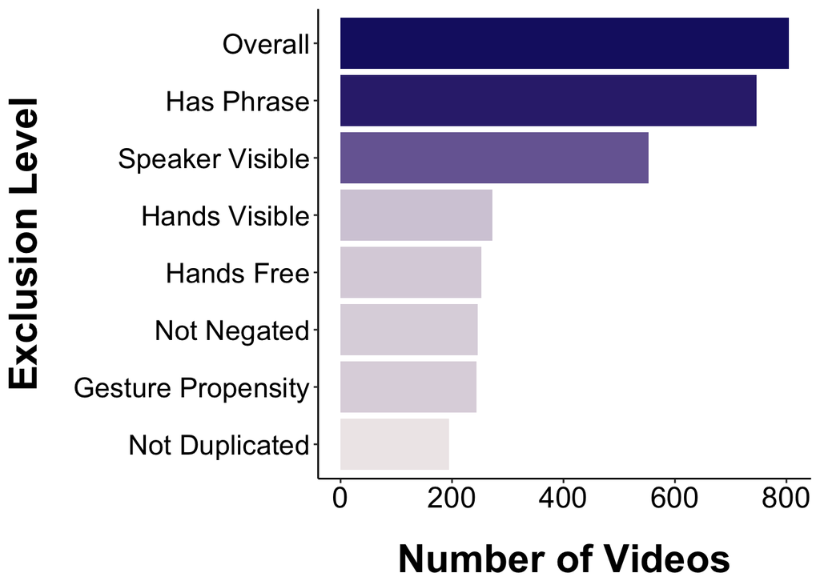

```r
# Create dataframe:
reduc <- data.frame(
  c("Overall", "Has Phrase", "Speaker Visible", "Hands Visible", "Hands Free", "Not Negated", "Gesture Propensity", "Not Duplicated"),
  c(804, 746, 553, 272, 253, 246, 244, 195))

# Preliminary work to make graph:
colnames(reduc) = c("level", "videos")    # Change column names
reduc$level <- factor(reduc$level, levels = c("Not Duplicated", "Gesture Propensity", "Not Negated", "Hands Free", "Hands Visible", "Speaker Visible", "Has Phrase", "Overall"))    # Create factor and order levels
bold.24.text <- element_text(size = 24, face = "bold")    # Create font style for axis titles
bold.21.text <- element_text(size = 19, face = "bold")    # Create font style for legend title
black.18.text <- element_text(size = 18, color = "black")    # Create font style for axis labels

# Make graph:
reduc %>%
  ggplot(aes(x = reduc$level, y = reduc$videos, fill = reduc$videos)) +
  geom_bar(stat = "identity", show.legend = FALSE) +
  coord_flip() +
  theme_classic() +
  xlab('Exclusion Level') +
  ylab('Number of Videos') +
  theme(axis.title = bold.24.text, axis.text.y = element_text(size = 17)) +
  theme(axis.text = black.18.text) +
  theme(axis.title.y = element_text(margin = margin(t = 0, r = 20, b = 0, l = 0))) +
  theme(axis.title.x = element_text(margin = margin(t = 20, r = 0, b = 0, l = 0))) +
  scale_fill_gradient(low = "snow2", high = "midnightblue")
```

Check how many unique speakers there are in dataset:

```r
length(unique(size$SpeakerName))
```

```
## [1] 166
```

## Hand configuration: tiny/huge

Let’s now look at hand configuration for each phrase. We hypothesise that speakers will perform proportionally more closed gestures when saying ‘tiny numbers’ and proportionally more open gestures when saying ‘huge numbers’.

```r
size2 <- filter(size, HandConfig != "object")    # Remove 'object' values
(xtab <- table(size2$Phrase, size2$HandConfig))    # Raw counts
```

```
##
##               closed open
##   huge_number     10   71
##   tiny_number     55   30
```

```r
round(prop.table(xtab, 1), 3) * 100    # Row-wise percentages
```

```
##
##               closed open
##   huge_number   12.3 87.7
##   tiny_number   64.7 35.3
```

Make a plot showing these results:

```r
# Preliminary work to make graph:
prop.table <- prop.table(xtab, 1)    # Row-wise percentages
xtab <- as.data.frame(prop.table)   # Turn table into dataframe
as.numeric(xtab$Freq)   # Turn Frequency into numeric variable
```

```
## [1] 0.1234568 0.6470588 0.8765432 0.3529412
```

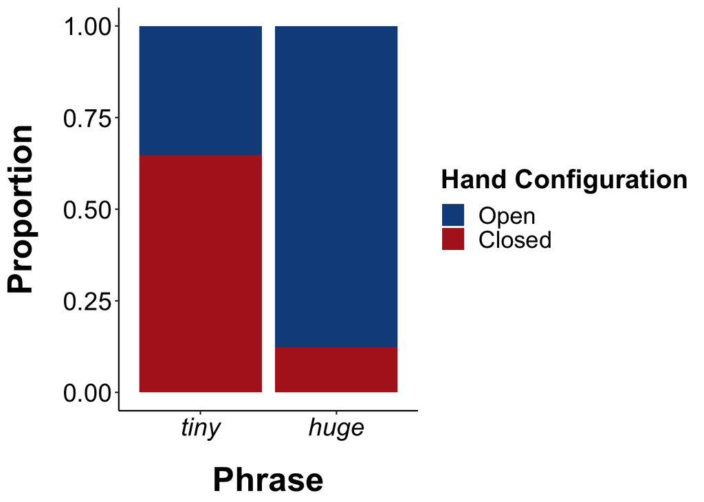

```r
xtab$Var1 <- factor(xtab$Var1, levels = c("tiny_number", "huge_number"))   # Turn x-axis variables into a factor and re-order variables
xtab$Var2 <- factor(xtab$Var2, levels = c('open', 'closed'))    # Turn legend variables into a factor

# Make graph:
xtab %>%
  ggplot(aes(x = xtab$Var1, y = Freq, fill = factor(Var2))) +
  geom_bar(stat = "identity") +
  theme_classic() +
  xlab('Phrase') +
  ylab('Proportion') +
  theme(axis.title = bold.24.text, legend.text = element_text(size = 17), legend.title = bold.21.text) +
  theme(axis.text = black.18.text, axis.text.x = element_text(face = "italic")) +
  theme(axis.title.y = element_text(margin = margin(t = 0, r = 20, b = 0, l = 0))) +
  theme(axis.title.x = element_text(margin = margin(t = 20, r = 0, b = 0, l = 0))) +
  scale_fill_manual(values = c('dodgerblue4', 'firebrick'), breaks = c("open","closed"), name = "Hand Configuration", labels = c("Open", "Closed")) +
  scale_x_discrete(labels = c('tiny', 'huge'))
```

These descriptive statistics would seem to support our hypothesis. Let’s check this with logistic regression:

```r
# Preliminaries:
size2$Phrase <- factor(size2$Phrase, levels = c("tiny_number", "huge_number"))    # Turn Phrase into a factor and re-order levels
size2$HandConfig <- as.factor(size2$HandConfig)   # Turn HandConfig into a factor

# Input, summarise and plot logistic regression model:
summary(LR <- glm(HandConfig ~ Phrase, data = size2, family = "binomial"))
```

```
##
## Call:
## glm(formula = HandConfig ~ Phrase, family = "binomial", data = size2)
##
## Deviance Residuals:
##     Min       1Q   Median       3Q      Max
## -2.0454  -0.9331   0.5134   0.5134   1.4432
##
## Coefficients:
##                   Estimate Std. Error z value Pr(>|z|)
## (Intercept)        -0.6061     0.2270  -2.671  0.00757 **
## Phrasehuge_number   2.5662     0.4069   6.306 2.86e-10 ***
## ---
## Signif. codes:  0 '***' 0.001 '**' 0.01 '*' 0.05 '.' 0.1 ' ' 1
##
## (Dispersion parameter for binomial family taken to be 1)
##
##     Null deviance: 222.26  on 165  degrees of freedom
## Residual deviance: 170.92  on 164  degrees of freedom
## AIC: 174.92
##
## Number of Fisher Scoring iterations: 4
```

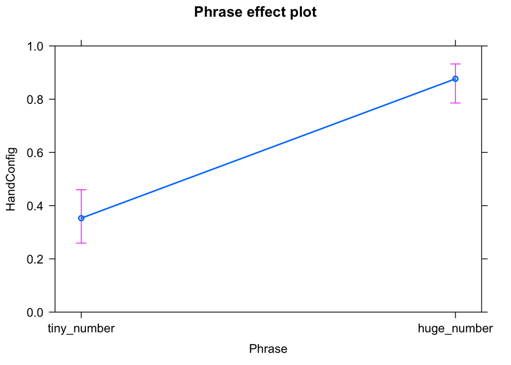

```r
plot(allEffects(LR), type = "response", ylim = c(0,1))   # Plot logistic regression model
```

This logistic regression model shows that, in line with our hypothesis, speakers were more likely to produce open gestures when saying ‘huge number’ than when saying ‘tiny number’, and vice versa.

However, because some speakers appeared in the dataset more than once, the independence assumption of this model is violated. To account for this, let’s run a for loop that simulates this test again 1000 times with random samples containing only unique speakers:

```r
set.seed(13)    # Make example reproducible
nsim <- 1000    # Create object containing information about number of simulations
loop_p <- numeric(length = nsim)    # Create numeric object to store p-values from simulations

for (i in 1:nsim) {
  size_loop <- sample_n(size2, size = nrow(size2))
  size_reduc <- filter(size_loop, !duplicated(SpeakerName))
  summary(LR <- glm(HandConfig ~ Phrase, data = size_reduc, family = "binomial"))
  loop_p[i] <- summary(LR)$coefficients[2,4]}

sum(loop_p < 0.05)    # Find number of p-values less than 0.05
```

```
## [1] 1000
```

All 1000 samples returned a statistically reliable result.

Out of interest, let’s see what specific types of closed gestures speakers used:

```r
# Pinch type:
(xtab <- table(size2$Phrase, size2$PinchType))
```

```
##
##               bunch bunch/pinch fist lobster_claw ok ok/pinch pinch point
##   tiny_number     7           1    2           14  5        1    23     2
##   huge_number     0           0    4            1  2        0     2     1
```

```r
round(prop.table(xtab, 1), 3) * 100
```

```
##
##               bunch bunch/pinch fist lobster_claw   ok ok/pinch pinch
##   tiny_number  12.7         1.8  3.6         25.5  9.1      1.8  41.8
##   huge_number   0.0         0.0 40.0         10.0 20.0      0.0  20.0
##
##               point
##   tiny_number   3.6
##   huge_number  10.0
```

```r
# Pinkie curl:
(xtab <- table(size2$Phrase, size2$PinkieCurl))
```

```
##
##               curled extended extended/curled
##   tiny_number     41       12               2
##   huge_number      8        2               0
```

```r
round(prop.table(xtab, 1), 3) * 100
```

```
##
##               curled extended extended/curled
##   tiny_number   74.5     21.8             3.6
##   huge_number   80.0     20.0             0.0
```

Interestingly, most of the closed gestures for ‘huge number’ were actually made with a clenched fist, which arguably does not imply any sort of size. Hardly any speakers gestured with a clenched fist when saying ‘tiny number’. For ‘tiny number’, speakers were most likely to use a pinch gesture, followed by a hand configuration resembling a lobster claw. The figures above for PinkieCurl don’t reveal any notable differences.

## Vertical movement: tiny/huge

Let’s now look at vertical movement for each phrase. We hypothesise that speakers will perform proportionally more downwards-moving gestures when saying ‘tiny numbers’ and proportionally more upwards-moving gestures when saying ‘huge numbers’.

```r
(xtab <- table(size$Phrase, size$MovementVertical))    # Raw counts
```

```
##
##               down up
##   huge_number   35  3
##   tiny_number   49 11
```

```r
round(prop.table(xtab, 1), 3) * 100    # Row-wise percentages
```

```
##
##               down   up
##   huge_number 92.1  7.9
##   tiny_number 81.7 18.3
```

These descriptive statistics suggest that the opposite is true: speakers actually produced proportionally more downwards-moving gestures when saying ‘huge number’, and proportionally more upwards-moving gestures when saying ‘tiny number’. On a side note, most gestures overall were downwards-moving, perhaps due to the presence of beat gestures in the dataset, which may often contain a downwards-moving component

Let’s check this with a logistic regression model:

```r
# Preliminaries:
size$Phrase <- factor(size$Phrase, levels = c("tiny_number", "huge_number"))    # Turn Phrase into a factor and re-order levels
size$MovementVertical <- as.factor(size$MovementVertical)   # Turn MovementVertical into a factor

# Input, summarise and plot logistic regression model:
summary(LR <- glm(MovementVertical ~ Phrase, data = size, family = "binomial"))
```

```
##
## Call:
## glm(formula = MovementVertical ~ Phrase, family = "binomial",
##     data = size)
##
## Deviance Residuals:
##     Min       1Q   Median       3Q      Max
## -0.6364  -0.6364  -0.5210  -0.4056   2.2534
##
## Coefficients:
##                   Estimate Std. Error z value Pr(>|z|)
## (Intercept)        -1.4939     0.3336  -4.478 7.55e-06 ***
## Phrasehuge_number  -0.9628     0.6879  -1.400    0.162
## ---
## Signif. codes:  0 '***' 0.001 '**' 0.01 '*' 0.05 '.' 0.1 ' ' 1
##
## (Dispersion parameter for binomial family taken to be 1)
##
##     Null deviance: 80.383  on 97  degrees of freedom
## Residual deviance: 78.160  on 96  degrees of freedom
##   (97 observations deleted due to missingness)
## AIC: 82.16
##
## Number of Fisher Scoring iterations: 5
```

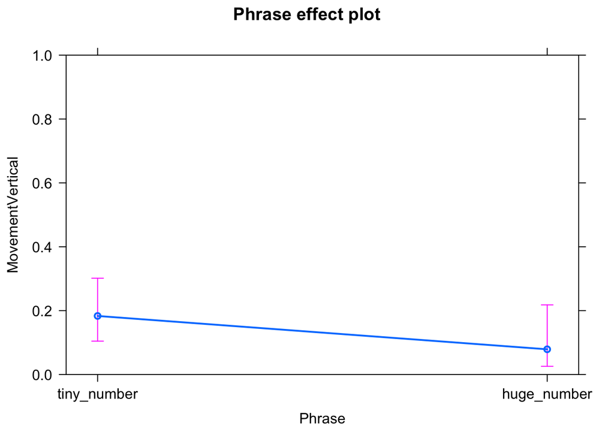

```r
plot(allEffects(LR), type = "response", ylim = c(0,1))   # Plot logistic regression model
```

This logistic regression model instead suggests that there is no statistically reliable relationship between phrase and vertical movement.

## One-handed vs. both-handed: tiny/huge

Let’s now look at one-handed versus both-handed gestures for each phrase. We hypothesise that speakers will produce proportionally more both-handed gestures when saying ‘huge number’, and proportionally more one-handed gestures when saying ‘tiny number’, in line with the principle of articulatory plurality.

```r
# Filter dataset to only those videos where both the speakers' hands are free to gesture:
size2 <- filter(size, HandsFree %in% c('both', 'both/object', 'both/oneobject'))    # HandsFree == 'both'

# Add column comparing one-handed versus both-handed gestures:
size2 <- mutate(size2, OneVsBoth = ifelse(WhichHand %in% c("L", "R"), "one", "both"))

# Check that it's worked by randomly sampling dataset:
set.seed(13)    # Make example reproducible
sample_n(size2, 10) %>%
  select(WhichHand, OneVsBoth)
```

```
## # A tibble: 10 x 2
##    WhichHand OneVsBoth
##    <chr>     <chr>
##  1 L         one
##  2 both      both
##  3 both      both
##  4 both      both
##  5 R         one
##  6 both      both
##  7 R         one
##  8 L         one
##  9 both      both
## 10 R         one
```

```r
# Look at raw counts and row-wise percentages
(xtab <- table(size2$Phrase, size2$OneVsBoth))    # Raw counts
```

```
##
##               both one
##   tiny_number   26  15
##   huge_number   51  12
```

```r
round(prop.table(xtab, 1), 3) * 100    # Row-wise percentages
```

```
##
##               both  one
##   tiny_number 63.4 36.6
##   huge_number 81.0 19.0
```

A look at these descriptive statistics suggests that our hypothesis may be valid. Before we check this, let’s also look at one-handed versus both-handed gestures across noun plurality, which is another way of investigating articulatory plurality. We hypothesise that speakers will produce proportionally more both-handed gestures alongside plural nouns (standards), and proportionally more one-handed gestures alongside singular nouns (standard).

```r
(xtab <- table(size2$NounPlural, size2$OneVsBoth))    # Raw counts
```

```
##
##       both one
##   no    50  21
##   yes   17   6
```

```r
round(prop.table(xtab, 1), 3) * 100    # Row-wise percentages
```

```
##
##       both  one
##   no  70.4 29.6
##   yes 73.9 26.1
```

Let’s now look at whether speakers gesture with one or both hands as a function of phrase and noun plurality:

```r
# Preliminaries:
size2$Phrase <- factor(size2$Phrase, levels = c("tiny_number", "huge_number"))    # Turn Phrase into a factor and re-order levels
size2$NounPlural <- as.factor(size2$NounPlural)     # Turn NounPlural into a factor
size2$OneVsBoth <- factor(size2$OneVsBoth, levels = c("one", "both"))   # Turn MovementVertical into a factor and re-order levels

# Input, summarise and plot logistic regression model:
summary(LR <- glm(OneVsBoth ~ Phrase + NounPlural, data = size2, family = "binomial"))
```

```
##
## Call:
## glm(formula = OneVsBoth ~ Phrase + NounPlural, family = "binomial",
##     data = size2)
##
## Deviance Residuals:
##     Min       1Q   Median       3Q      Max
## -1.7521  -1.3852   0.6967   0.9152   1.0018
##
## Coefficients:
##                   Estimate Std. Error z value Pr(>|z|)
## (Intercept)        0.47620    0.33719   1.412   0.1579
## Phrasehuge_number  0.81598    0.47774   1.708   0.0876 .
## NounPluralyes     -0.04811    0.56575  -0.085   0.9322
## ---
## Signif. codes:  0 '***' 0.001 '**' 0.01 '*' 0.05 '.' 0.1 ' ' 1
##
## (Dispersion parameter for binomial family taken to be 1)
##
##     Null deviance: 112.74  on 93  degrees of freedom
## Residual deviance: 109.67  on 91  degrees of freedom
##   (10 observations deleted due to missingness)
## AIC: 115.67
##
## Number of Fisher Scoring iterations: 4
```

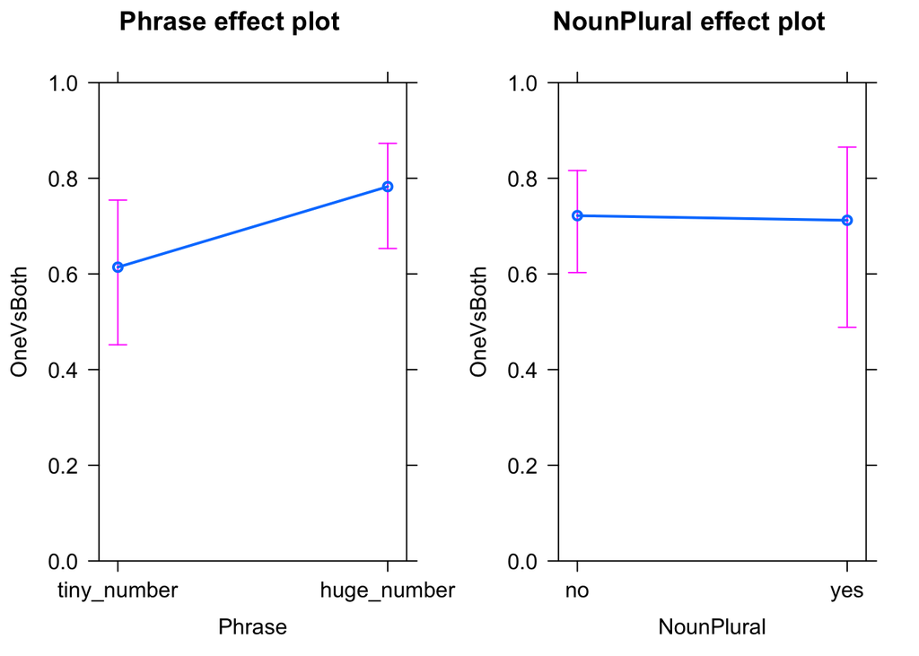

```r
plot(allEffects(LR), type = "response", ylim = c(0,1))   # Plot logistic regression model
```

This model reveals no statistically reliable relationship between whether a speaker gestures with one or both hands and phrase or noun plurality.

## Orders of magnitude: tiny/huge

Let’s now look at orders of magnitude by creating an additional column in the dataset that takes the logarithmic value in powers of ten of the QuantityValue column:

```r
size2 <- filter(size, QuantityType == 'number')   # Only look at 'number' values
size2$QuantityValue <- as.numeric(size2$QuantityValue)    # Turn QuantityValue into numeric vector
size2 <- mutate(size2, Magnitude = log10(QuantityValue))    # Create column taking the log10 of QuantityValue
size2$Magnitude <- as.numeric(substr(size2$Magnitude, 1,2))    # Print only first two digits
select(size2, QuantityValue, Magnitude)    # Look at QuantityValue and Magnitude columns
```

```
## # A tibble: 30 x 2
##    QuantityValue Magnitude
##            <dbl>     <dbl>
##  1             7         0
##  2            50         1
##  3         10000         4
##  4       7000000         6
##  5         22004         4
##  6         10000         4
##  7            17         1
##  8       1000000         6
##  9       1000000         6
## 10      30000000         7
## # ... with 20 more rows
```

Look at Magnitude across Phrase:

```r
(xtab <- table(size2$Phrase, size2$Magnitude))    # Raw figures
```

```
##
##               0 1 2 3 4 6 7 9 10 13
##   tiny_number 1 2 3 1 2 2 0 2  0  0
##   huge_number 1 4 0 1 3 3 3 0  1  1
```

```r
round(prop.table(xtab, 1), 3) * 100   # Row-wise percentages
```

```
##
##                  0    1    2    3    4    6    7    9   10   13
##   tiny_number  7.7 15.4 23.1  7.7 15.4 15.4  0.0 15.4  0.0  0.0
##   huge_number  5.9 23.5  0.0  5.9 17.6 17.6 17.6  0.0  5.9  5.9
```

Look at HandConfig across Phrase:

```r
(xtab <- table(size2$HandConfig, size2$Magnitude))    # Raw figures
```

```
##
##          0 1 2 3 4 6 7 9 10 13
##   closed 0 0 2 0 1 0 0 1  0  0
##   open   1 5 0 1 3 5 2 1  1  1
```

```r
round(prop.table(xtab, 1), 3) * 100   # Row-wise percentages
```

```
##
##           0  1  2  3  4  6  7  9 10 13
##   closed  0  0 50  0 25  0  0 25  0  0
##   open    5 25  0  5 15 25 10  5  5  5
```

```r
(xtab <- table(size2$MovementVertical, size2$Magnitude))    # Raw figures
```

```
##
##        0 1 2 3 4 6 7 9 10 13
##   down 1 1 1 1 1 4 1 0  1  0
##   up   0 0 0 0 0 0 0 1  0  1
```

```r
round(prop.table(xtab, 1), 3) * 100   # Row-wise percentages
```

```
##
##           0    1    2    3    4    6    7    9   10   13
##   down  9.1  9.1  9.1  9.1  9.1 36.4  9.1  0.0  9.1  0.0
##   up    0.0  0.0  0.0  0.0  0.0  0.0  0.0 50.0  0.0 50.0
```

This seems to show that whether a speaker describes a number as ‘tiny’ or ‘huge’ is dependent on relative rather than absolute quantity. Likewise, whether a speaker uses a closed or open hand shape also seems to depend on relative rather than absolute quantity. Not much can be said about vertical movement because of the low numbers.

Let’s look at gesture co-occurrence as a function of magnitude:

```r
(xtab <- table(size2$HandsMoving, size2$Magnitude))    # Raw figures
```

```
##
##       0 1 2 3 4 6 7 9 10 13
##   no  1 1 1 1 1 0 1 0  0  0
##   yes 1 5 2 1 4 5 2 2  1  1
```

```r
round(prop.table(xtab, 1), 3) * 100   # Row-wise percentages
```

```
##
##          0    1    2    3    4    6    7    9   10   13
##   no  16.7 16.7 16.7 16.7 16.7  0.0 16.7  0.0  0.0  0.0
##   yes  4.2 20.8  8.3  4.2 16.7 20.8  8.3  8.3  4.2  4.2
```

Absolute magnitude does not seem to predict gesture co-occurrence.

## Palm orientation: tiny/huge

Now, let’s look at palm orientation for each phrase:

```r
(xtab <- table(size$Phrase, size$PalmOrientation))    # Raw counts
```

```
##
##               back down front inward up
##   tiny_number    1    5     0     14 10
##   huge_number   11   15     2     34  9
```

```r
round(prop.table(xtab, 1), 3) * 100    # Row-wise percentages
```

```
##
##               back down front inward   up
##   tiny_number  3.3 16.7   0.0   46.7 33.3
##   huge_number 15.5 21.1   2.8   47.9 12.7
```

Not much interesting going on. Most gestures are inward. There are proportionally more upwards-facing gestures for ‘tiny number’, and proportionally more backwards-facing gestures for ‘huge number’.

# Low vs. high

Load low/high numbers dataset and give it a shorter name for easier coding:

```r
(height <- read_csv('highlow_alldata_coded.csv'))
```

```
## # A tibble: 869 x 31
##       ID URL   Archive_ID Title SpeakerName HasPhrase Phrase Negated Plural
##    <int> <chr> <chr>      <chr> <chr>       <chr>     <chr>  <chr>   <chr>
##  1   795 http… CSPAN2_20… Book… peter berg… yes       low_n… no      no
##  2   814 http… MSNBC_201… MSNB… morgan bre… yes       low_n… no      yes
##  3   249 http… WBFF_2010… Fox … no          yes       high_… no      no
##  4   720 http… CNN_20110… In t… michio kaku yes       low_n… no      yes
##  5   556 http… CSPAN2_20… U.S.… richard ha… yes       low_n… no      no
##  6   449 http… KPIX_2014… KPIX… kiet do     yes       high_… no      no
##  7   636 http… CSPAN2_20… U.S.… cristina l… yes       low_n… no      yes
##  8   117 http… CSPAN2_20… Toni… ray lahood  yes       high_… no      no
##  9   566 http… CSPAN_201… U.S.… sheila jac… yes       low_n… no      no
## 10   607 http… FOXNEWSW_… Amer… no          yes       low_n… no      no
## # ... with 859 more rows, and 22 more variables: SpeakerVisible <chr>,
## #   HandsVisible <chr>, HandsVisibleGenerous <chr>, HandsFree <chr>,
## #   HandsMoving <chr>, NounPlural <chr>, ContextMove <chr>,
## #   Duplicated <chr>, WhichHand <chr>, HandConfig <chr>, PinchType <chr>,
## #   PinkieCurl <chr>, PalmOrientation <chr>, MovementVertical <chr>,
## #   MovementHorizontal <chr>, MovementSagittal <chr>, QuantityType <chr>,
## #   QuantityValue <chr>, VerbatimReferent <chr>, QuantityContrast <chr>,
## #   OfInterest <chr>, Comments <chr>
```

Reduce dataset to only those videos which were analysable from a gestural perspective:

```r
# Overall:
nrow(height)
```

```
## [1] 869
```

```r
# HasPhrase == "yes":
height <- filter(height, HasPhrase != "no")
nrow(height)    # 1280 videos
```

```
## [1] 813
```

```r
# SpeakerVisible == "yes":
height <- filter(height, SpeakerVisible != "no")
nrow(height)    # 950 videos
```

```
## [1] 530
```

```r
# HandsVisibleGenerous == "one" or "both":
height <- filter(height, HandsVisibleGenerous != "neither")
nrow(height)    # 499 videos
```

```
## [1] 214
```

```r
# HandsFree == "one" or "both":
height <- filter(height, HandsFree != "neither")
nrow(height)    # 425 videos
```

```
## [1] 176
```

```r
# Negated == 'NA' or "no":
height <- filter(height, is.na(Negated) | Negated != "yes")
nrow(height)    # 410 videos
```

```
## [1] 174
```

```r
# ContextMove == 'NA' or 'yes' videos:
height <- filter(height, is.na(ContextMove) | ContextMove != "no")
nrow(height)    # 387 videos
```

```
## [1] 165
```

Find out which speakers appear in the dataset more than once so duplicated videos can be removed manually:

```r
n_occur <- data.frame(table(height$SpeakerName))    # Create table of all speakers
filter(n_occur, Freq > 1 & Var1 != 'no')   # Filter to only those speakers that appear more than once and remove 'no' values
```

```
##                  Var1 Freq
## 1       bill o'reilly    2
## 2          jim cramer    2
## 3          john myers    2
## 4           karl rove    2
## 5       rachel maddow    3
## 6           roy blunt    2
## 7        sean hannity    4
## 8  sheila jackson lee    3
## 9        steve fertig    2
## 10      steve liesman    3
## 11         tom coburn    2
```

Remove duplicated videos from dataset:

```r
height <- filter(height, is.na(Duplicated) | Duplicated != "yes")
nrow(height)
```

```
## [1] 165
```

Create a plot showing reduction in size of dataset from 869 videos to 165 videos:

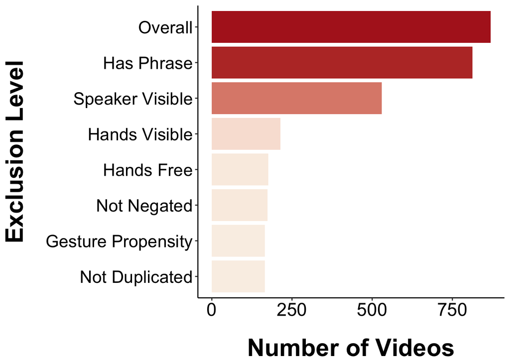

```r
# Create dataframe:
reduc <- data.frame(
  c("Overall", "Has Phrase", "Speaker Visible", "Hands Visible", "Hands Free", "Not Negated", "Gesture Propensity", "Not Duplicated"),
  c(869, 813, 530, 214, 176, 174, 165, 165))

# Preliminary work to make graph:
colnames(reduc) = c("level", "videos")    # Change column names
reduc$level <- factor(reduc$level, levels = c("Not Duplicated", "Gesture Propensity", "Not Negated", "Hands Free", "Hands Visible", "Speaker Visible", "Has Phrase", "Overall"))    # Create factor and order levels
bold.24.text <- element_text(size = 24, face = "bold")    # Create font style for axis titles
bold.21.text <- element_text(size = 19, face = "bold")    # Create font style for legend title
black.18.text <- element_text(size = 18, color = "black")    # Create font style for axis labels

# Make graph:
reduc %>%
  ggplot(aes(x = reduc$level, y = reduc$videos, fill = reduc$videos)) +
  geom_bar(stat = "identity", show.legend = FALSE) +
  coord_flip() +
  theme_classic() +
  xlab('Exclusion Level') +
  ylab('Number of Videos') +
  theme(axis.title = bold.24.text, axis.text.y = element_text(size = 17)) +
  theme(axis.text = black.18.text) +
  theme(axis.title.y = element_text(margin = margin(t = 0, r = 20, b = 0, l = 0))) +
  theme(axis.title.x = element_text(margin = margin(t = 20, r = 0, b = 0, l = 0))) +
  scale_fill_gradient(low = "linen", high = "firebrick")
```

Check how many unique speakers there are in dataset:

```r
length(unique(height$SpeakerName))
```

```
## [1] 123
```

## Vertical movement: low/high

Let’s now look at vertical movement for each phrase. We hypothesise that speakers will produce proportionally more downwards-moving gestures when saying ‘low number’ and proportionally more upwards-moving gestures when saying ‘high number’.

```r
(xtab <- table(height$Phrase, height$MovementVertical))    # Raw counts
```

```
##
##               down up
##   high_number   29 13
##   low_number    38  3
```

```r
round(prop.table(xtab, 1), 3) * 100    # Row-wise percentages
```

```
##
##               down   up
##   high_number 69.0 31.0
##   low_number  92.7  7.3
```

Create plot to show these figures:

```r
# Preliminary work to make graph:
prop.table <- prop.table(xtab, 1)    # Row-wise percentages
xtab <- as.data.frame(prop.table)   # Turn table into dataframe
as.numeric(xtab$Freq)   # Turn Frequency into numeric variable
```

```
## [1] 0.69047619 0.92682927 0.30952381 0.07317073
```

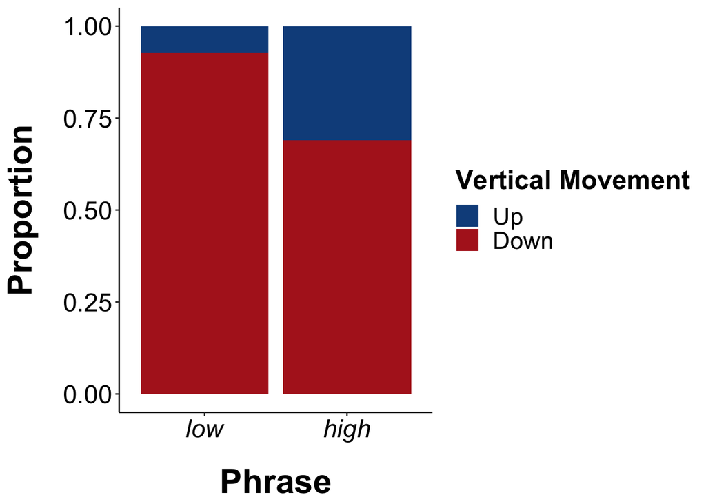

```r
xtab$Var1 <- factor(xtab$Var1, levels = c("low_number", "high_number"))   # Turn x-axis variables into a factor and re-order variables
xtab$Var2 <- factor(xtab$Var2, levels = c('up', 'down'))    # Turn legend variables into a factor

# Make graph:
xtab %>%
  ggplot(aes(x = xtab$Var1, y = Freq, fill = factor(Var2))) +
  geom_bar(stat = "identity") +
  theme_classic() +
  xlab('Phrase') +
  ylab('Proportion') +
  theme(axis.title = bold.24.text, legend.text = element_text(size = 17), legend.title = bold.21.text) +
  theme(axis.text = black.18.text, axis.text.x = element_text(face = "italic")) +
  theme(axis.title.y = element_text(margin = margin(t = 0, r = 20, b = 0, l = 0))) +
  theme(axis.title.x = element_text(margin = margin(t = 20, r = 0, b = 0, l = 0))) +
  scale_fill_manual(values = c('dodgerblue4', 'firebrick'), breaks = c("up","down"), name = "Vertical Movement", labels = c("Up", "Down")) +
  scale_x_discrete(labels = c('low', 'high'))
```

These descriptive statistics suggest that, although downwards-moving gestures were more prevalent overall, downwards-moving gestures were in fact preferred for the phrase ‘low number’ compared to ‘high number’. Let’s check this with logistic regression:

```r
# Preliminaries:
height$Phrase <- factor(height$Phrase, levels = c("low_number", "high_number"))    # Turn Phrase into a factor and re-order levels
height$MovementVertical <- as.factor(height$MovementVertical)   # Turn MovementVertical into a factor

# Input, summarise and plot logistic regression model:
summary(LR <- glm(MovementVertical ~ Phrase, data = height, family = "binomial"))
```

```
##
## Call:
## glm(formula = MovementVertical ~ Phrase, family = "binomial",
##     data = height)
##
## Deviance Residuals:
##     Min       1Q   Median       3Q      Max
## -0.8607  -0.8607  -0.3898  -0.3898   2.2869
##
## Coefficients:
##                   Estimate Std. Error z value Pr(>|z|)
## (Intercept)        -2.5390     0.5997  -4.234  2.3e-05 ***
## Phrasehigh_number   1.7366     0.6863   2.530   0.0114 *
## ---
## Signif. codes:  0 '***' 0.001 '**' 0.01 '*' 0.05 '.' 0.1 ' ' 1
##
## (Dispersion parameter for binomial family taken to be 1)
##
##     Null deviance: 81.376  on 82  degrees of freedom
## Residual deviance: 73.437  on 81  degrees of freedom
##   (82 observations deleted due to missingness)
## AIC: 77.437
##
## Number of Fisher Scoring iterations: 5
```

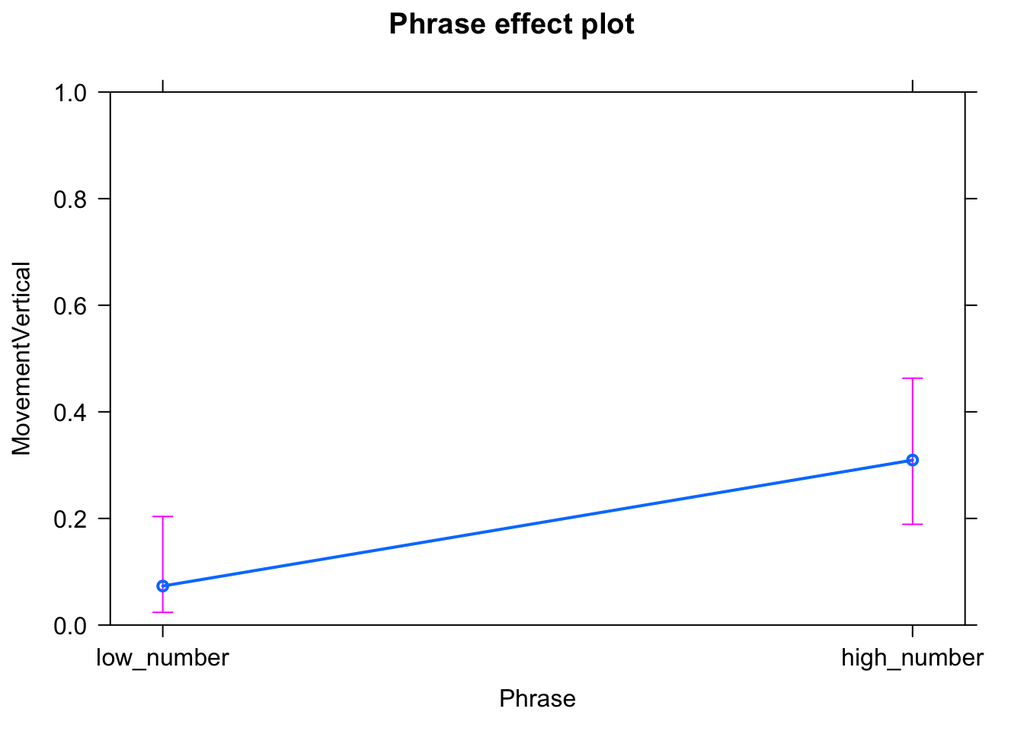

```r
plot(allEffects(LR), type = "response", ylim = c(0,1))   # Plot logistic regression model
```

These results confirm our above interpretation of the descriptive statistics. Let’s now sample the dataset 1000 times with only unique speakers and perform this test again:

```r
set.seed(13)    # Make example reproducible
nsim <- 1000    # Create object containing information about number of simulations
loop_p <- numeric(length = nsim)    # Create numeric object to store p-values from simulations

for (i in 1:nsim) {
  height_loop <- sample_n(height, size = nrow(height))
  height_reduc <- filter(height_loop, !duplicated(SpeakerName))
  summary(LR <- glm(MovementVertical ~ Phrase, data = height_reduc, family = "binomial"))
  loop_p[i] <- summary(LR)$coefficients[2,4]}

sum(loop_p < 0.05)    # Find number of p-values less than 0.05
```

```
## [1] 868
```

868 samples returned a statistically reliable result, which suggests that although repeated speakers may have contributed to the effect we observed overall, this effect is still fairly robust. Perhaps this effect is less robust than the tiny-closed and huge-open hand gestures we saw because the adjectives ‘low’ and ‘high’ do not themselves encode vertical movement.

## Hand configuration: low/high

Now, let’s look at hand configuration for each phrase. We hypothesise that speakers will produce proportionally more closed gestures when saying ‘low number’, and proportionally more open gestures when saying ‘high number’.

```r
height2 <- filter(height, HandConfig %in% c("closed", "open"))    # Remove 'object' and 'object/open' values
(xtab <- table(height2$Phrase, height2$HandConfig))    # Raw counts
```

```
##
##               closed open
##   low_number      12   45
##   high_number     12   55
```

```r
round(prop.table(xtab, 1), 3) * 100    # Row-wise percentages
```

```
##
##               closed open
##   low_number    21.1 78.9
##   high_number   17.9 82.1
```

These are only small differences, but there is a slight trend in the direction of our hypothesis. Let’s check this with logistic regression:

```r
# Preliminaries:
height2$Phrase <- factor(height2$Phrase, levels = c("low_number", "high_number"))    # Turn Phrase into a factor and re-order levels
height2$HandConfig <- as.factor(height2$HandConfig)   # Turn MovementVertical into a factor

# Input, summarise and plot logistic regression model:
summary(LR <- glm(HandConfig ~ Phrase, data = height2, family = "binomial"))
```

```
##
## Call:
## glm(formula = HandConfig ~ Phrase, family = "binomial", data = height2)
##
## Deviance Residuals:
##     Min       1Q   Median       3Q      Max
## -1.8546   0.6283   0.6283   0.6876   0.6876
##
## Coefficients:
##                   Estimate Std. Error z value Pr(>|z|)
## (Intercept)         1.3218     0.3249   4.068 4.74e-05 ***
## Phrasehigh_number   0.2007     0.4551   0.441    0.659
## ---
## Signif. codes:  0 '***' 0.001 '**' 0.01 '*' 0.05 '.' 0.1 ' ' 1
##
## (Dispersion parameter for binomial family taken to be 1)
##
##     Null deviance: 121.85  on 123  degrees of freedom
## Residual deviance: 121.65  on 122  degrees of freedom
## AIC: 125.65
##
## Number of Fisher Scoring iterations: 4
```

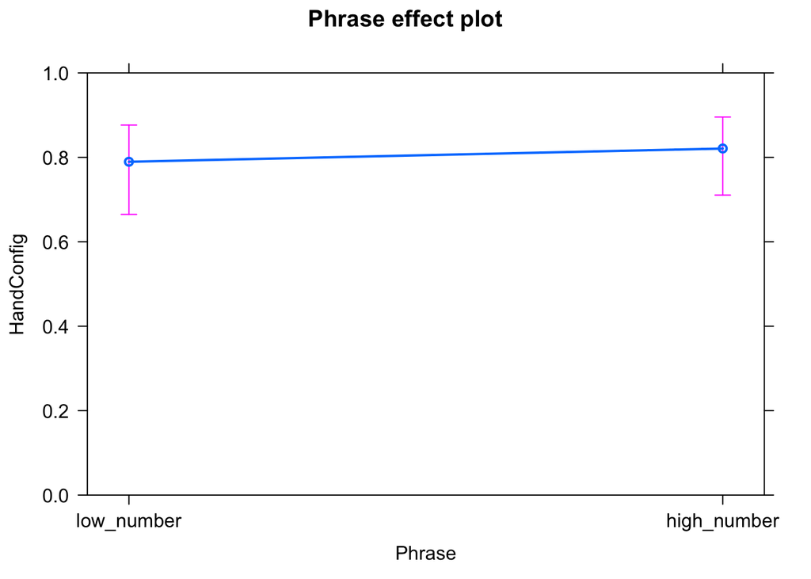

```r
plot(allEffects(LR), type = "response", ylim = c(0,1))   # Plot logistic regression model
```

Unsurprisingly due to the small differences, this test reveals no statistically reliable effect.

Out of interest, let’s see what specific types of closed gestures speakers used:

```r
# Pinch type:
(xtab <- table(height2$Phrase, height2$PinchType))
```

```
##
##               bunch fist lobster_claw pinch point
##   low_number      1    1            1     4     5
##   high_number     2    2            2     1     5
```

```r
round(prop.table(xtab, 1), 3) * 100
```

```
##
##               bunch fist lobster_claw pinch point
##   low_number    8.3  8.3          8.3  33.3  41.7
##   high_number  16.7 16.7         16.7   8.3  41.7
```

```r
# Pinkie curl:
(xtab <- table(height2$Phrase, height2$PinkieCurl))
```

```
##
##               curled extended
##   low_number      11        1
##   high_number     10        2
```

```r
round(prop.table(xtab, 1), 3) * 100
```

```
##
##               curled extended
##   low_number    91.7      8.3
##   high_number   83.3     16.7
```

The numbers here aren’t really high enough to make any clear inferences (there weren’t many closed gestures overall in this dataset), but there doesn’t seem to be a massive difference between ‘low number’ and ‘high number’, which reinforces the previous result. People didn’t see to have a small-big schema in mind when using these phrases.

## One-handed vs. both-handed: low/high

Let’s now look at one-handed versus both-handed gestures for each phrase. We hypothesise that speakers will produce proportionally more both-handed gestures when saying ‘high number’, and proportionally more one-handed gestures when saying ‘low number’, in line with the principle of articulatory plurality.

```r
# Filter dataset to only those videos where both the speakers' hands are free to gesture:
height2 <- filter(height, HandsFree %in% c('both', 'both/object', 'both/oneobject'))    # HandsFree == 'both'

# Add column comparing one-handed versus both-handed gestures:
height2 <- mutate(height2, OneVsBoth = ifelse(WhichHand %in% c("L", "R"), "one", "both"))

# Check to see if it's worked by randomly sampling dataset:
set.seed(13)    # Make example reproducible
sample_n(height2, 10) %>%
  select(WhichHand, OneVsBoth)
```

```
## # A tibble: 10 x 2
##    WhichHand OneVsBoth
##    <chr>     <chr>
##  1 both      both
##  2 both      both
##  3 <NA>      both
##  4 <NA>      both
##  5 L         one
##  6 both      both
##  7 both      both
##  8 R         one
##  9 both      both
## 10 both      both
```

```r
# Look at raw counts and row-wise percentages
(xtab <- table(height2$Phrase, height2$OneVsBoth))    # Raw counts
```

```
##
##               both one
##   low_number    40   7
##   high_number   34  12
```

```r
round(prop.table(xtab, 1), 3) * 100    # Row-wise percentages
```

```
##
##               both  one
##   low_number  85.1 14.9
##   high_number 73.9 26.1
```

The opposite actually appears to be true: speakers produced proportionally more both-handed gestures when saying ‘low number’, and proportionally more one-handed gestures when saying ‘high number’.

Before we check this with logistic regression, let’s look at whether speakers produce one- or both-handed gestures as a function of noun plurality, which is another way of examining articulatory plurality. We hypothesise that speakers will produce proportionally more one-handed gestures when using a singular noun (‘number’), and proportionally more both-handed gestures when using a plural noun (‘numbers’).

```r
(xtab <- table(height2$NounPlural, height2$OneVsBoth))    # Raw counts
```

```
##
##       both one
##   no    28  10
##   yes   16   9
```

```r
round(prop.table(xtab, 1), 3) * 100    # Row-wise percentages
```

```
##
##       both  one
##   no  73.7 26.3
##   yes 64.0 36.0
```

Again, these descriptive statistics actually show a trend in the opposite direction of our hypothesis. Let’s now look at whether speakers gesture with one or both hands as a function of phrase and noun plurality:

```r
# Preliminaries:
height2$Phrase <- factor(height2$Phrase, levels = c("low_number", "high_number"))    # Turn Phrase into a factor and re-order levels
height2$NounPlural <- as.factor(height2$NounPlural)     # Turn NounPlural into a factor
height2$OneVsBoth <- factor(height2$OneVsBoth, levels = c("one", "both"))   # Turn MovementVertical into a factor and re-order levels

# Input, summarise and plot logistic regression model:
summary(LR <- glm(OneVsBoth ~ Phrase + NounPlural, data = height2, family = "binomial"))
```

```
##
## Call:
## glm(formula = OneVsBoth ~ Phrase + NounPlural, family = "binomial",
##     data = height2)
##
## Deviance Residuals:
##     Min       1Q   Median       3Q      Max
## -1.9955  -1.0788   0.8152   0.9066   1.2793
##
## Coefficients:
##                   Estimate Std. Error z value Pr(>|z|)
## (Intercept)         1.8442     0.6187   2.981  0.00288 **
## Phrasehigh_number  -1.1676     0.6410  -1.822  0.06853 .
## NounPluralyes      -0.9130     0.6399  -1.427  0.15363
## ---
## Signif. codes:  0 '***' 0.001 '**' 0.01 '*' 0.05 '.' 0.1 ' ' 1
##
## (Dispersion parameter for binomial family taken to be 1)
##
##     Null deviance: 77.138  on 62  degrees of freedom
## Residual deviance: 72.880  on 60  degrees of freedom
##   (30 observations deleted due to missingness)
## AIC: 78.88
##
## Number of Fisher Scoring iterations: 4
```

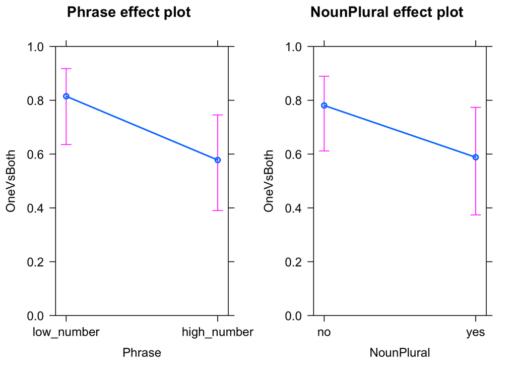

```r
plot(allEffects(LR), type = "response", ylim = c(0,1))   # Plot logistic regression model
```

This logistic regression model reveals no statistically reliable trend in either direction.

## Orders of magnitude: low/high

Let’s now look at orders of magnitude by creating an additional column in the dataset that takes the logarithmic value in powers of ten of the QuantityValue column:

```r
height2 <- filter(height, QuantityType == 'number')   # Only look at 'number' values
height2$QuantityValue <- as.numeric(height2$QuantityValue)    # Turn QuantityValue into numeric vector
height2 <- mutate(height2, Magnitude = log10(QuantityValue))    # Create column taking the log10 of QuantityValue
height2$Magnitude <- as.numeric(substr(height2$Magnitude, 1,2))    # Print only first two digits
select(height2, QuantityValue, Magnitude)   # Look at QuantityValue and Magnitude columns
```

```
## # A tibble: 50 x 2
##    QuantityValue Magnitude
##            <dbl>     <dbl>
##  1       5.00e 1         1
##  2       1.90e 6         6
##  3       3.70e 1         1
##  4       1.00e 6         6
##  5       1.00e 3         3
##  6       2.50e 0         0
##  7       3.58e 5         5
##  8       1.00e 9         9
##  9       6.00e 0         0
## 10       1.00e12        12
## # ... with 40 more rows
```

Look at Magnitude across Phrase:

```r
(xtab <- table(height2$Phrase, height2$Magnitude))    # Raw figures
```

```
##
##                0  1  2  3  4  5  6  7  8  9 10 11 12
##   low_number   3 12  2  1  3  1  1  1  0  1  1  0  1
##   high_number  1  7  1  2  0  2  3  2  1  2  0  2  0
```

```r
round(prop.table(xtab, 1), 3) * 100   # Row-wise percentages
```

```
##
##                  0    1    2    3    4    5    6    7    8    9   10   11
##   low_number  11.1 44.4  7.4  3.7 11.1  3.7  3.7  3.7  0.0  3.7  3.7  0.0
##   high_number  4.3 30.4  4.3  8.7  0.0  8.7 13.0  8.7  4.3  8.7  0.0  8.7
##
##                 12
##   low_number   3.7
##   high_number  0.0
```

Look at HandConfig across Phrase:

```r
(xtab <- table(height2$HandConfig, height2$Magnitude))    # Raw figures
```

```
##
##           0  1  2  3  4  5  6  7  8  9 10 11 12
##   closed  2  3  1  1  0  0  1  1  1  0  0  1  0
##   open    2 11  0  2  0  1  2  1  0  2  1  0  1
```

```r
round(prop.table(xtab, 1), 3) * 100   # Row-wise percentages
```

```
##
##             0    1    2    3    4    5    6    7    8    9   10   11   12
##   closed 18.2 27.3  9.1  9.1  0.0  0.0  9.1  9.1  9.1  0.0  0.0  9.1  0.0
##   open    8.7 47.8  0.0  8.7  0.0  4.3  8.7  4.3  0.0  8.7  4.3  0.0  4.3
```

Look at MovementVertical across Phrase:

```r
(xtab <- table(height2$MovementVertical, height2$Magnitude))    # Raw figures
```

```
##
##        0 1 2 3 4 5 6 7 8 9 10 11 12
##   down 2 7 0 1 0 0 2 0 1 1  0  1  1
##   up   0 2 0 1 0 0 0 1 0 0  0  0  0
```

```r
round(prop.table(xtab, 1), 3) * 100   # Row-wise percentages
```

```
##
##           0    1    2    3    4    5    6    7    8    9   10   11   12
##   down 12.5 43.8  0.0  6.2  0.0  0.0 12.5  0.0  6.2  6.2  0.0  6.2  6.2
##   up    0.0 50.0  0.0 25.0  0.0  0.0  0.0 25.0  0.0  0.0  0.0  0.0  0.0
```

This seems to show that whether a speaker describes a number as ‘low’ or ‘high’ is dependent on relative rather than absolute quantity. Likewise, whether a speaker uses a closed or open hand shape also seems to depend on relative rather than absolute quantity. Not much can be said about vertical movement because of the low numbers.

Let’s look at gesture co-occurrence as a function of magnitude:

```r
(xtab <- table(height2$HandsMoving, height2$Magnitude))    # Raw figures
```

```
##
##        0  1  2  3  4  5  6  7  8  9 10 11 12
##   no   1  6  2  0  3  2  2  1  0  1  0  1  0
##   yes  3 13  1  3  0  1  2  2  1  2  1  1  1
```

```r
round(prop.table(xtab, 1), 3) * 100   # Row-wise percentages
```

```
##
##          0    1    2    3    4    5    6    7    8    9   10   11   12
##   no   5.3 31.6 10.5  0.0 15.8 10.5 10.5  5.3  0.0  5.3  0.0  5.3  0.0
##   yes  9.7 41.9  3.2  9.7  0.0  3.2  6.5  6.5  3.2  6.5  3.2  3.2  3.2
```

There doesn’t seem to be any clear pattern here.

## Palm orientation: low/high

Look at palm orientation for each phrase:

```r
(xtab <- table(height$Phrase, height$PalmOrientation))    # Raw counts
```

```
##
##               back down front inward inward/down up up/down
##   low_number     9   14     4     15           1  3       0
##   high_number    6   11     6     25           0  6       1
```

```r
round(prop.table(xtab, 1), 3) * 100    # Row-wise percentages
```

```
##
##               back down front inward inward/down   up up/down
##   low_number  19.6 30.4   8.7   32.6         2.2  6.5     0.0
##   high_number 10.9 20.0  10.9   45.5         0.0 10.9     1.8
```

Again, there’s nothing much interesting going on here.

# Tests on both datasets

Join both tibbles:

```r
# Join tibbles
full <- full_join(size, height)
# Check that it's worked:
set.seed(13)    # Make example reproducible
sample_n(full, 10) %>%
  select(Phrase)
```

```
## # A tibble: 10 x 1
##    Phrase
##    <chr>
##  1 low_number
##  2 tiny_number
##  3 huge_number
##  4 huge_number
##  5 high_number
##  6 tiny_number
##  7 low_number
##  8 low_number
##  9 high_number
## 10 huge_number
```

## Gesture co-occurrence:

Let’s compare gesture co-occurrence per dataset. We hypothesise that speakers will be more likely to gesture when saying ‘tiny/huge number’ because these descriptors are more extreme than ‘low/high number’.

```r
# Create new column for tiny and huge vs. low and high:
full <- mutate(full, SizeVsHeight = ifelse(Phrase %in% c('tiny_number', 'huge_number'), 'size', 'height'))

# Check that it's worked:
set.seed(13)    # Make example reproducible
sample_n(full, 10) %>%
  select(Phrase, SizeVsHeight)
```

```
## # A tibble: 10 x 2
##    Phrase      SizeVsHeight
##    <chr>       <chr>
##  1 low_number  height
##  2 tiny_number size
##  3 huge_number size
##  4 huge_number size
##  5 high_number height
##  6 tiny_number size
##  7 low_number  height
##  8 low_number  height
##  9 high_number height
## 10 huge_number size
```

```r
# Compare gesture co-occurrence across size and height phrases:
(xtab <- table(full$SizeVsHeight, full$HandsMoving))    # Raw counts
```

```
##
##           no yes
##   height  42 122
##   size    18 170
```

```r
round(prop.table(xtab, 1), 3) * 100    # Row-wise percentages
```

```
##
##            no  yes
##   height 25.6 74.4
##   size    9.6 90.4
```

Descriptively, it does seem to be the case that speakers gesture more when saying ‘tiny/huge number’. Let’s check this with a logistic regression model:

```r
# Preliminaries:
full$SizeVsHeight <- as.factor(full$SizeVsHeight)    # Turn SizeVsHeight into a factor
full$HandsMoving <- as.factor(full$HandsMoving)     # Turn HandsMoving into a factor

# Input, summarise and plot logistic regression model:
summary(LR <- glm(HandsMoving ~ SizeVsHeight, data = full, family = "binomial"))
```

```
##
## Call:
## glm(formula = HandsMoving ~ SizeVsHeight, family = "binomial",
##     data = full)
##
## Deviance Residuals:
##     Min       1Q   Median       3Q      Max
## -2.1661   0.4486   0.4486   0.7692   0.7692
##
## Coefficients:
##                  Estimate Std. Error z value Pr(>|z|)
## (Intercept)        1.0664     0.1789   5.961 2.51e-09 ***
## SizeVsHeightsize   1.1791     0.3057   3.857 0.000115 ***
## ---
## Signif. codes:  0 '***' 0.001 '**' 0.01 '*' 0.05 '.' 0.1 ' ' 1
##
## (Dispersion parameter for binomial family taken to be 1)
##
##     Null deviance: 321.45  on 351  degrees of freedom
## Residual deviance: 305.29  on 350  degrees of freedom
##   (8 observations deleted due to missingness)
## AIC: 309.29
##
## Number of Fisher Scoring iterations: 4
```

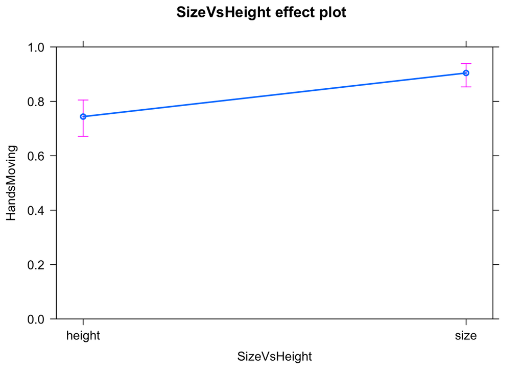

```r
plot(allEffects(LR), type = "response", ylim = c(0,1))   # Plot logistic regression model
```

This model supports our above interpretation of the data.

Out of interest, let’s look at gesture co-occurrence across individual phrases:

```r
(xtab <- table(full$Phrase, full$HandsMoving))    # Raw counts
```

```
##
##               no yes
##   high_number 20  65
##   huge_number 12  82
##   low_number  22  57
##   tiny_number  6  88
```

```r
round(prop.table(xtab, 1), 3) * 100    # Row-wise percentages
```

```
##
##                 no  yes
##   high_number 23.5 76.5
##   huge_number 12.8 87.2
##   low_number  27.8 72.2
##   tiny_number  6.4 93.6
```

Not too much going on here except for the difference between the ‘size’ and ‘height’ datasets we already witnessed. Let’s make a graph to show this:

```r
# Preliminary work to make graph:
prop.table <- prop.table(xtab, 1)    # Row-wise percentages
xtab <- as.data.frame(prop.table)   # Turn table into dataframe
as.numeric(xtab$Freq)   # Turn Frequency into numeric variable
```

```
## [1] 0.23529412 0.12765957 0.27848101 0.06382979 0.76470588 0.87234043
## [7] 0.72151899 0.93617021
```

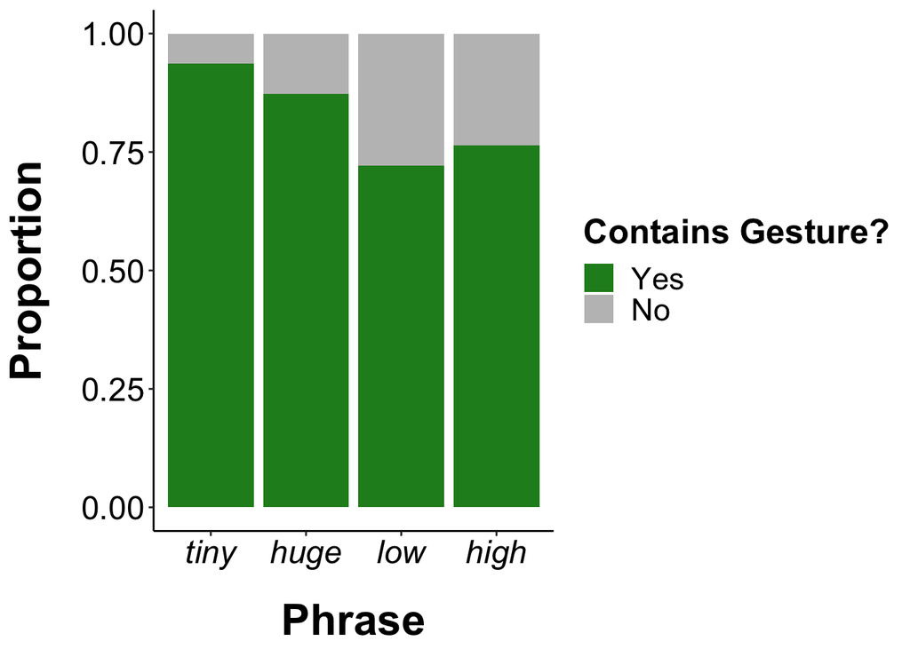

```r
xtab$Var1 <- factor(xtab$Var1, levels = c("tiny_number", "huge_number", "low_number", "high_number"))   # Re-order x-axis variables
xtab$Var2 <- factor(xtab$Var2, levels = c("no", "yes"))    # Re-order legend variables

# Make graph:
xtab %>%
  ggplot(aes(x = xtab$Var1, y = Freq, fill = factor(Var2))) +
  geom_bar(stat = "identity") +
  theme_classic() +
  xlab('Phrase') +
  ylab('Proportion') +
  theme(axis.title = bold.24.text, legend.text = element_text(size = 17), legend.title = bold.21.text) +
  theme(axis.text = black.18.text, axis.text.x = element_text(face = "italic")) +
  theme(axis.title.y = element_text(margin = margin(t = 0, r = 20, b = 0, l = 0))) +
  theme(axis.title.x = element_text(margin = margin(t = 20, r = 0, b = 0, l = 0))) +
  scale_fill_manual(values = c('grey75', 'forestgreen'), breaks = c("yes","no"), name = "Contains Gesture?", labels = c("Yes", "No")) +
  scale_x_discrete(labels = c('tiny', 'huge', 'low', 'high'))
```